# Optimal Treatment Analysis

## Outcome Variable

**Outcome Variable:** ever_stunted

## Predictor Variables

**Intervention Variable:** anywast06

**Adjustment Set:**

- arm
- sex
- W_mage
- meducyrs
- month
- brthmon
- W_parity
- delta_W_mage
- delta_meducyrs
- delta_month
- delta_brthmon
- delta_W_parity

## Stratifying Variables

The analysis was stratified on these variable(s):

- agecat
- studyid
- country

## Data Summary

| agecat | studyid | country | anywast06 | ever_stunted | n_cell | n |
| --- | --- | --- | --- | --- | --- | --- |
| 0-24 months (no birth st.) | ki0047075b-MAL-ED | BANGLADESH | 0 | 0 | 76 | 217 |
| 0-24 months (no birth st.) | ki0047075b-MAL-ED | BANGLADESH | 0 | 1 | 92 | 217 |
| 0-24 months (no birth st.) | ki0047075b-MAL-ED | BANGLADESH | 1 | 0 | 28 | 217 |
| 0-24 months (no birth st.) | ki0047075b-MAL-ED | BANGLADESH | 1 | 1 | 21 | 217 |
| 0-24 months (no birth st.) | ki0047075b-MAL-ED | BRAZIL | 0 | 0 | 167 | 208 |
| 0-24 months (no birth st.) | ki0047075b-MAL-ED | BRAZIL | 0 | 1 | 27 | 208 |
| 0-24 months (no birth st.) | ki0047075b-MAL-ED | BRAZIL | 1 | 0 | 12 | 208 |
| 0-24 months (no birth st.) | ki0047075b-MAL-ED | BRAZIL | 1 | 1 | 2 | 208 |
| 0-24 months (no birth st.) | ki0047075b-MAL-ED | INDIA | 0 | 0 | 62 | 209 |
| 0-24 months (no birth st.) | ki0047075b-MAL-ED | INDIA | 0 | 1 | 82 | 209 |
| 0-24 months (no birth st.) | ki0047075b-MAL-ED | INDIA | 1 | 0 | 39 | 209 |
| 0-24 months (no birth st.) | ki0047075b-MAL-ED | INDIA | 1 | 1 | 26 | 209 |
| 0-24 months (no birth st.) | ki0047075b-MAL-ED | NEPAL | 0 | 0 | 132 | 212 |
| 0-24 months (no birth st.) | ki0047075b-MAL-ED | NEPAL | 0 | 1 | 45 | 212 |
| 0-24 months (no birth st.) | ki0047075b-MAL-ED | NEPAL | 1 | 0 | 25 | 212 |
| 0-24 months (no birth st.) | ki0047075b-MAL-ED | NEPAL | 1 | 1 | 10 | 212 |
| 0-24 months (no birth st.) | ki0047075b-MAL-ED | PERU | 0 | 0 | 112 | 266 |
| 0-24 months (no birth st.) | ki0047075b-MAL-ED | PERU | 0 | 1 | 146 | 266 |
| 0-24 months (no birth st.) | ki0047075b-MAL-ED | PERU | 1 | 0 | 3 | 266 |
| 0-24 months (no birth st.) | ki0047075b-MAL-ED | PERU | 1 | 1 | 5 | 266 |
| 0-24 months (no birth st.) | ki0047075b-MAL-ED | SOUTH AFRICA | 0 | 0 | 124 | 280 |
| 0-24 months (no birth st.) | ki0047075b-MAL-ED | SOUTH AFRICA | 0 | 1 | 127 | 280 |
| 0-24 months (no birth st.) | ki0047075b-MAL-ED | SOUTH AFRICA | 1 | 0 | 19 | 280 |
| 0-24 months (no birth st.) | ki0047075b-MAL-ED | SOUTH AFRICA | 1 | 1 | 10 | 280 |
| 0-24 months (no birth st.) | ki0047075b-MAL-ED | TANZANIA, UNITED REPUBLIC OF | 0 | 0 | 40 | 219 |
| 0-24 months (no birth st.) | ki0047075b-MAL-ED | TANZANIA, UNITED REPUBLIC OF | 0 | 1 | 170 | 219 |
| 0-24 months (no birth st.) | ki0047075b-MAL-ED | TANZANIA, UNITED REPUBLIC OF | 1 | 0 | 1 | 219 |
| 0-24 months (no birth st.) | ki0047075b-MAL-ED | TANZANIA, UNITED REPUBLIC OF | 1 | 1 | 8 | 219 |
| 0-24 months (no birth st.) | ki1000108-CMC-V-BCS-2002 | INDIA | 0 | 0 | 19 | 293 |
| 0-24 months (no birth st.) | ki1000108-CMC-V-BCS-2002 | INDIA | 0 | 1 | 118 | 293 |

[output cut: 198 more lines]

The following strata were considered:

- agecat: 0-24 months (no birth st.), studyid: ki0047075b-MAL-ED, country: BANGLADESH
- agecat: 0-24 months (no birth st.), studyid: ki0047075b-MAL-ED, country: BRAZIL
- agecat: 0-24 months (no birth st.), studyid: ki0047075b-MAL-ED, country: INDIA
- agecat: 0-24 months (no birth st.), studyid: ki0047075b-MAL-ED, country: NEPAL
- agecat: 0-24 months (no birth st.), studyid: ki0047075b-MAL-ED, country: PERU
- agecat: 0-24 months (no birth st.), studyid: ki0047075b-MAL-ED, country: SOUTH AFRICA
- agecat: 0-24 months (no birth st.), studyid: ki0047075b-MAL-ED, country: TANZANIA, UNITED REPUBLIC OF
- agecat: 0-24 months (no birth st.), studyid: ki1000108-CMC-V-BCS-2002, country: INDIA
- agecat: 0-24 months (no birth st.), studyid: ki1000108-IRC, country: INDIA
- agecat: 0-24 months (no birth st.), studyid: ki1000109-EE, country: PAKISTAN
- agecat: 0-24 months (no birth st.), studyid: ki1000109-ResPak, country: PAKISTAN
- agecat: 0-24 months (no birth st.), studyid: ki1017093b-PROVIDE, country: BANGLADESH
- agecat: 0-24 months (no birth st.), studyid: ki1066203-TanzaniaChild2, country: TANZANIA, UNITED REPUBLIC OF
- agecat: 0-24 months (no birth st.), studyid: ki1101329-Keneba, country: GAMBIA
- agecat: 0-24 months (no birth st.), studyid: ki1112895-Guatemala BSC, country: GUATEMALA
- agecat: 0-24 months (no birth st.), studyid: ki1113344-GMS-Nepal, country: NEPAL
- agecat: 0-24 months (no birth st.), studyid: ki1114097-CMIN, country: BANGLADESH
- agecat: 0-24 months (no birth st.), studyid: ki1114097-CMIN, country: PERU
- agecat: 0-24 months (no birth st.), studyid: ki1114097-CONTENT, country: PERU
- agecat: 0-6 months (no birth st.), studyid: ki0047075b-MAL-ED, country: BANGLADESH
- agecat: 0-6 months (no birth st.), studyid: ki0047075b-MAL-ED, country: BRAZIL
- agecat: 0-6 months (no birth st.), studyid: ki0047075b-MAL-ED, country: INDIA
- agecat: 0-6 months (no birth st.), studyid: ki0047075b-MAL-ED, country: NEPAL
- agecat: 0-6 months (no birth st.), studyid: ki0047075b-MAL-ED, country: PERU
- agecat: 0-6 months (no birth st.), studyid: ki0047075b-MAL-ED, country: SOUTH AFRICA
- agecat: 0-6 months (no birth st.), studyid: ki0047075b-MAL-ED, country: TANZANIA, UNITED REPUBLIC OF
- agecat: 0-6 months (no birth st.), studyid: ki1000108-CMC-V-BCS-2002, country: INDIA
- agecat: 0-6 months (no birth st.), studyid: ki1000108-IRC, country: INDIA
- agecat: 0-6 months (no birth st.), studyid: ki1000109-EE, country: PAKISTAN
- agecat: 0-6 months (no birth st.), studyid: ki1000109-ResPak, country: PAKISTAN
- agecat: 0-6 months (no birth st.), studyid: ki1017093b-PROVIDE, country: BANGLADESH
- agecat: 0-6 months (no birth st.), studyid: ki1066203-TanzaniaChild2, country: TANZANIA, UNITED REPUBLIC OF
- agecat: 0-6 months (no birth st.), studyid: ki1101329-Keneba, country: GAMBIA
- agecat: 0-6 months (no birth st.), studyid: ki1112895-Guatemala BSC, country: GUATEMALA
- agecat: 0-6 months (no birth st.), studyid: ki1113344-GMS-Nepal, country: NEPAL
- agecat: 0-6 months (no birth st.), studyid: ki1114097-CMIN, country: BANGLADESH
- agecat: 0-6 months (no birth st.), studyid: ki1114097-CMIN, country: PERU
- agecat: 0-6 months (no birth st.), studyid: ki1114097-CONTENT, country: PERU
- agecat: 6-24 months, studyid: ki0047075b-MAL-ED, country: BANGLADESH
- agecat: 6-24 months, studyid: ki0047075b-MAL-ED, country: BRAZIL
- agecat: 6-24 months, studyid: ki0047075b-MAL-ED, country: INDIA
- agecat: 6-24 months, studyid: ki0047075b-MAL-ED, country: NEPAL
- agecat: 6-24 months, studyid: ki0047075b-MAL-ED, country: PERU
- agecat: 6-24 months, studyid: ki0047075b-MAL-ED, country: SOUTH AFRICA
- agecat: 6-24 months, studyid: ki0047075b-MAL-ED, country: TANZANIA, UNITED REPUBLIC OF
- agecat: 6-24 months, studyid: ki1000108-CMC-V-BCS-2002, country: INDIA
- agecat: 6-24 months, studyid: ki1000108-IRC, country: INDIA
- agecat: 6-24 months, studyid: ki1000109-EE, country: PAKISTAN
- agecat: 6-24 months, studyid: ki1000109-ResPak, country: PAKISTAN
- agecat: 6-24 months, studyid: ki1017093b-PROVIDE, country: BANGLADESH
- agecat: 6-24 months, studyid: ki1066203-TanzaniaChild2, country: TANZANIA, UNITED REPUBLIC OF
- agecat: 6-24 months, studyid: ki1101329-Keneba, country: GAMBIA
- agecat: 6-24 months, studyid: ki1112895-Guatemala BSC, country: GUATEMALA
- agecat: 6-24 months, studyid: ki1113344-GMS-Nepal, country: NEPAL
- agecat: 6-24 months, studyid: ki1114097-CMIN, country: BANGLADESH
- agecat: 6-24 months, studyid: ki1114097-CMIN, country: PERU
- agecat: 6-24 months, studyid: ki1114097-CONTENT, country: PERU

### Dropped Strata

Some strata were dropped due to rare outcomes:

- agecat: 0-24 months (no birth st.), studyid: ki0047075b-MAL-ED, country: BRAZIL
- agecat: 0-24 months (no birth st.), studyid: ki0047075b-MAL-ED, country: PERU
- agecat: 0-24 months (no birth st.), studyid: ki0047075b-MAL-ED, country: TANZANIA, UNITED REPUBLIC OF
- agecat: 0-24 months (no birth st.), studyid: ki1112895-Guatemala BSC, country: GUATEMALA
- agecat: 0-24 months (no birth st.), studyid: ki1114097-CONTENT, country: PERU
- agecat: 0-6 months (no birth st.), studyid: ki0047075b-MAL-ED, country: BRAZIL
- agecat: 0-6 months (no birth st.), studyid: ki0047075b-MAL-ED, country: NEPAL
- agecat: 0-6 months (no birth st.), studyid: ki0047075b-MAL-ED, country: PERU
- agecat: 0-6 months (no birth st.), studyid: ki0047075b-MAL-ED, country: SOUTH AFRICA
- agecat: 0-6 months (no birth st.), studyid: ki0047075b-MAL-ED, country: TANZANIA, UNITED REPUBLIC OF
- agecat: 0-6 months (no birth st.), studyid: ki1112895-Guatemala BSC, country: GUATEMALA
- agecat: 0-6 months (no birth st.), studyid: ki1114097-CONTENT, country: PERU
- agecat: 6-24 months, studyid: ki0047075b-MAL-ED, country: BRAZIL
- agecat: 6-24 months, studyid: ki0047075b-MAL-ED, country: PERU
- agecat: 6-24 months, studyid: ki0047075b-MAL-ED, country: TANZANIA, UNITED REPUBLIC OF
- agecat: 6-24 months, studyid: ki1112895-Guatemala BSC, country: GUATEMALA
- agecat: 6-24 months, studyid: ki1114097-CONTENT, country: PERU

## Methods Detail

We’re interested in the causal parameters $E[Y_a]$ for all values of $a \in \mathcal{A}$. These parameters represent the mean outcome if, possibly contrary to fact, we intervened to set all units to have $A=a$. Under the randomization and positivity assumptions, these are identified by the statistical parameters $\psi_a=E_W[E_{Y|A,W}(Y|A=a,W)]$. In addition, we’re interested in the mean of $Y$, $E[Y]$ under no intervention (the observed mean). We will estimate these parameters by using SuperLearner to fit the relevant likelihood factors – $E_{Y|A,W}(Y|A=a,W)$ and $p(A=a|W)$, and then updating our likelihood fit using a joint TMLE.

For unadjusted analyses ($W=\{\}$), initial likelihoods were estimated using Lrnr_glm to estimate the simple $E(Y|A)$ and Lrnr_mean to estimate $p(A)$. For adjusted analyses, a small library containing Lrnr_glmnet, Lrnr_xgboost, and Lrnr_mean was used.

# Results Detail

## Results Plots

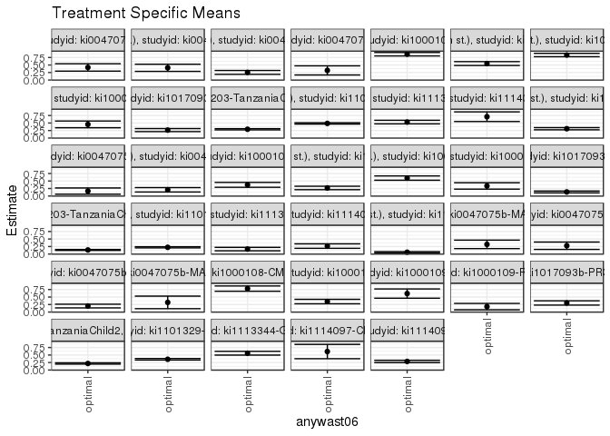

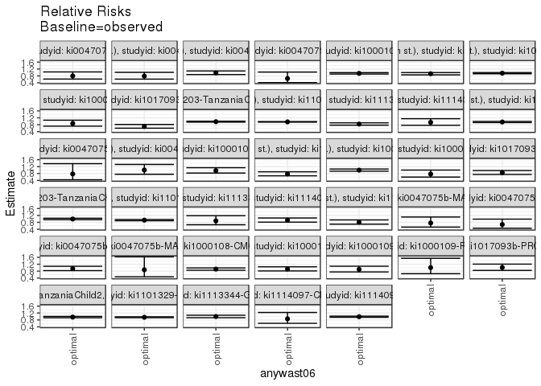

## Results Table

### Parameter: TSM

| agecat | studyid | country | intervention_level | baseline_level | estimate | ci_lower | ci_upper |
| --- | --- | --- | --- | --- | --- | --- | --- |
| 0-24 months (no birth st.) | ki0047075b-MAL-ED | BANGLADESH | optimal | NA | 0.4186908 | 0.2959200 | 0.5414616 |
| 0-24 months (no birth st.) | ki0047075b-MAL-ED | INDIA | optimal | NA | 0.4069995 | 0.2875575 | 0.5264414 |
| 0-24 months (no birth st.) | ki0047075b-MAL-ED | NEPAL | optimal | NA | 0.2534929 | 0.1892775 | 0.3177084 |
| 0-24 months (no birth st.) | ki0047075b-MAL-ED | SOUTH AFRICA | optimal | NA | 0.3199285 | 0.1680986 | 0.4717585 |
| 0-24 months (no birth st.) | ki1000108-CMC-V-BCS-2002 | INDIA | optimal | NA | 0.8597548 | 0.8017812 | 0.9177283 |
| 0-24 months (no birth st.) | ki1000108-IRC | INDIA | optimal | NA | 0.5483061 | 0.4832703 | 0.6133420 |
| 0-24 months (no birth st.) | ki1000109-EE | PAKISTAN | optimal | NA | 0.8319946 | 0.7754862 | 0.8885029 |
| 0-24 months (no birth st.) | ki1000109-ResPak | PAKISTAN | optimal | NA | 0.4534404 | 0.3409624 | 0.5659184 |
| 0-24 months (no birth st.) | ki1017093b-PROVIDE | BANGLADESH | optimal | NA | 0.2641027 | 0.2132521 | 0.3149533 |
| 0-24 months (no birth st.) | ki1066203-TanzaniaChild2 | TANZANIA, UNITED REPUBLIC OF | optimal | NA | 0.2918752 | 0.2715985 | 0.3121520 |
| 0-24 months (no birth st.) | ki1101329-Keneba | GAMBIA | optimal | NA | 0.4868991 | 0.4643753 | 0.5094229 |
| 0-24 months (no birth st.) | ki1113344-GMS-Nepal | NEPAL | optimal | NA | 0.5307083 | 0.4707929 | 0.5906237 |
| 0-24 months (no birth st.) | ki1114097-CMIN | BANGLADESH | optimal | NA | 0.7096946 | 0.5494311 | 0.8699580 |
| 0-24 months (no birth st.) | ki1114097-CMIN | PERU | optimal | NA | 0.3096512 | 0.2730456 | 0.3462568 |
| 0-6 months (no birth st.) | ki0047075b-MAL-ED | BANGLADESH | optimal | NA | 0.1647500 | 0.0610219 | 0.2684781 |
| 0-6 months (no birth st.) | ki0047075b-MAL-ED | INDIA | optimal | NA | 0.2082684 | 0.1345374 | 0.2819995 |
| 0-6 months (no birth st.) | ki1000108-CMC-V-BCS-2002 | INDIA | optimal | NA | 0.3719029 | 0.2909300 | 0.4528757 |
| 0-6 months (no birth st.) | ki1000108-IRC | INDIA | optimal | NA | 0.2684084 | 0.2104125 | 0.3264043 |
| 0-6 months (no birth st.) | ki1000109-EE | PAKISTAN | optimal | NA | 0.5978162 | 0.5265895 | 0.6690428 |
| 0-6 months (no birth st.) | ki1000109-ResPak | PAKISTAN | optimal | NA | 0.3354675 | 0.2290008 | 0.4419342 |
| 0-6 months (no birth st.) | ki1017093b-PROVIDE | BANGLADESH | optimal | NA | 0.1356899 | 0.1050890 | 0.1662909 |
| 0-6 months (no birth st.) | ki1066203-TanzaniaChild2 | TANZANIA, UNITED REPUBLIC OF | optimal | NA | 0.1358996 | 0.1206189 | 0.1511803 |
| 0-6 months (no birth st.) | ki1101329-Keneba | GAMBIA | optimal | NA | 0.2236533 | 0.2048495 | 0.2424571 |
| 0-6 months (no birth st.) | ki1113344-GMS-Nepal | NEPAL | optimal | NA | 0.1652361 | 0.1085388 | 0.2219335 |
| 0-6 months (no birth st.) | ki1114097-CMIN | BANGLADESH | optimal | NA | 0.2646318 | 0.1908144 | 0.3384491 |
| 0-6 months (no birth st.) | ki1114097-CMIN | PERU | optimal | NA | 0.0602526 | 0.0414008 | 0.0791045 |
| 6-24 months | ki0047075b-MAL-ED | BANGLADESH | optimal | NA | 0.3217864 | 0.1803428 | 0.4632300 |
| 6-24 months | ki0047075b-MAL-ED | INDIA | optimal | NA | 0.2766359 | 0.1537378 | 0.3995340 |
| 6-24 months | ki0047075b-MAL-ED | NEPAL | optimal | NA | 0.2000873 | 0.1385708 | 0.2616038 |
| 6-24 months | ki0047075b-MAL-ED | SOUTH AFRICA | optimal | NA | 0.3206804 | 0.1110008 | 0.5303599 |
| 6-24 months | ki1000108-CMC-V-BCS-2002 | INDIA | optimal | NA | 0.7807463 | 0.6928198 | 0.8686727 |
| 6-24 months | ki1000108-IRC | INDIA | optimal | NA | 0.3489598 | 0.2744603 | 0.4234594 |
| 6-24 months | ki1000109-EE | PAKISTAN | optimal | NA | 0.6147368 | 0.4602996 | 0.7691741 |
| 6-24 months | ki1000109-ResPak | PAKISTAN | optimal | NA | 0.1804655 | 0.0743104 | 0.2866206 |
| 6-24 months | ki1017093b-PROVIDE | BANGLADESH | optimal | NA | 0.3025036 | 0.2308715 | 0.3741358 |
| 6-24 months | ki1066203-TanzaniaChild2 | TANZANIA, UNITED REPUBLIC OF | optimal | NA | 0.2182676 | 0.1964343 | 0.2401009 |
| 6-24 months | ki1101329-Keneba | GAMBIA | optimal | NA | 0.3587064 | 0.3331110 | 0.3843018 |
| 6-24 months | ki1113344-GMS-Nepal | NEPAL | optimal | NA | 0.5603958 | 0.4975522 | 0.6232394 |
| 6-24 months | ki1114097-CMIN | BANGLADESH | optimal | NA | 0.6164789 | 0.3781557 | 0.8548022 |
| 6-24 months | ki1114097-CMIN | PERU | optimal | NA | 0.2859883 | 0.2477062 | 0.3242703 |

### Parameter: E(Y)

| agecat | studyid | country | intervention_level | baseline_level | estimate | ci_lower | ci_upper |
| --- | --- | --- | --- | --- | --- | --- | --- |
| 0-24 months (no birth st.) | ki0047075b-MAL-ED | BANGLADESH | observed | NA | 0.5242810 | 0.4576590 | 0.5909029 |
| 0-24 months (no birth st.) | ki0047075b-MAL-ED | INDIA | observed | NA | 0.5169223 | 0.4490109 | 0.5848337 |
| 0-24 months (no birth st.) | ki0047075b-MAL-ED | NEPAL | observed | NA | 0.2595724 | 0.2004296 | 0.3187153 |
| 0-24 months (no birth st.) | ki0047075b-MAL-ED | SOUTH AFRICA | observed | NA | 0.4919789 | 0.4333224 | 0.5506354 |
| 0-24 months (no birth st.) | ki1000108-CMC-V-BCS-2002 | INDIA | observed | NA | 0.9074125 | 0.8742374 | 0.9405875 |
| 0-24 months (no birth st.) | ki1000108-IRC | INDIA | observed | NA | 0.5921241 | 0.5412792 | 0.6429689 |
| 0-24 months (no birth st.) | ki1000109-EE | PAKISTAN | observed | NA | 0.8682347 | 0.8260353 | 0.9104342 |
| 0-24 months (no birth st.) | ki1000109-ResPak | PAKISTAN | observed | NA | 0.5197463 | 0.4506780 | 0.5888147 |
| 0-24 months (no birth st.) | ki1017093b-PROVIDE | BANGLADESH | observed | NA | 0.3783048 | 0.3405830 | 0.4160267 |
| 0-24 months (no birth st.) | ki1066203-TanzaniaChild2 | TANZANIA, UNITED REPUBLIC OF | observed | NA | 0.2991375 | 0.2801550 | 0.3181199 |
| 0-24 months (no birth st.) | ki1101329-Keneba | GAMBIA | observed | NA | 0.5043897 | 0.4836522 | 0.5251272 |
| 0-24 months (no birth st.) | ki1113344-GMS-Nepal | NEPAL | observed | NA | 0.6337026 | 0.5928376 | 0.6745676 |
| 0-24 months (no birth st.) | ki1114097-CMIN | BANGLADESH | observed | NA | 0.7569764 | 0.6918325 | 0.8221204 |
| 0-24 months (no birth st.) | ki1114097-CMIN | PERU | observed | NA | 0.3233951 | 0.2876177 | 0.3591726 |
| 0-6 months (no birth st.) | ki0047075b-MAL-ED | BANGLADESH | observed | NA | 0.2122855 | 0.1577802 | 0.2667908 |
| 0-6 months (no birth st.) | ki0047075b-MAL-ED | INDIA | observed | NA | 0.2079729 | 0.1525692 | 0.2633765 |
| 0-6 months (no birth st.) | ki1000108-CMC-V-BCS-2002 | INDIA | observed | NA | 0.3835656 | 0.3276975 | 0.4394338 |
| 0-6 months (no birth st.) | ki1000108-IRC | INDIA | observed | NA | 0.3464217 | 0.2972670 | 0.3955765 |
| 0-6 months (no birth st.) | ki1000109-EE | PAKISTAN | observed | NA | 0.6003117 | 0.5394020 | 0.6612213 |
| 0-6 months (no birth st.) | ki1000109-ResPak | PAKISTAN | observed | NA | 0.4352734 | 0.3667257 | 0.5038210 |
| 0-6 months (no birth st.) | ki1017093b-PROVIDE | BANGLADESH | observed | NA | 0.1594321 | 0.1309231 | 0.1879410 |
| 0-6 months (no birth st.) | ki1066203-TanzaniaChild2 | TANZANIA, UNITED REPUBLIC OF | observed | NA | 0.1369870 | 0.1227324 | 0.1512416 |
| 0-6 months (no birth st.) | ki1101329-Keneba | GAMBIA | observed | NA | 0.2413615 | 0.2236155 | 0.2591075 |
| 0-6 months (no birth st.) | ki1113344-GMS-Nepal | NEPAL | observed | NA | 0.1868195 | 0.1537545 | 0.2198845 |
| 0-6 months (no birth st.) | ki1114097-CMIN | BANGLADESH | observed | NA | 0.2864069 | 0.2178909 | 0.3549228 |
| 0-6 months (no birth st.) | ki1114097-CMIN | PERU | observed | NA | 0.0746022 | 0.0545276 | 0.0946768 |
| 6-24 months | ki0047075b-MAL-ED | BANGLADESH | observed | NA | 0.4225241 | 0.3455306 | 0.4995175 |
| 6-24 months | ki0047075b-MAL-ED | INDIA | observed | NA | 0.4114211 | 0.3336592 | 0.4891829 |
| 6-24 months | ki0047075b-MAL-ED | NEPAL | observed | NA | 0.2110626 | 0.1537217 | 0.2684036 |
| 6-24 months | ki0047075b-MAL-ED | SOUTH AFRICA | observed | NA | 0.3648589 | 0.2898009 | 0.4399170 |
| 6-24 months | ki1000108-CMC-V-BCS-2002 | INDIA | observed | NA | 0.8511210 | 0.7990764 | 0.9031656 |
| 6-24 months | ki1000108-IRC | INDIA | observed | NA | 0.3776014 | 0.3156351 | 0.4395678 |
| 6-24 months | ki1000109-EE | PAKISTAN | observed | NA | 0.6801202 | 0.5868391 | 0.7734012 |
| 6-24 months | ki1000109-ResPak | PAKISTAN | observed | NA | 0.1798193 | 0.1023317 | 0.2573070 |
| 6-24 months | ki1017093b-PROVIDE | BANGLADESH | observed | NA | 0.2999508 | 0.2578989 | 0.3420026 |
| 6-24 months | ki1066203-TanzaniaChild2 | TANZANIA, UNITED REPUBLIC OF | observed | NA | 0.2260198 | 0.2055339 | 0.2465057 |
| 6-24 months | ki1101329-Keneba | GAMBIA | observed | NA | 0.3752695 | 0.3512888 | 0.3992503 |
| 6-24 months | ki1113344-GMS-Nepal | NEPAL | observed | NA | 0.5613942 | 0.5142136 | 0.6085749 |
| 6-24 months | ki1114097-CMIN | BANGLADESH | observed | NA | 0.7125084 | 0.6278603 | 0.7971565 |
| 6-24 months | ki1114097-CMIN | PERU | observed | NA | 0.2895789 | 0.2522254 | 0.3269324 |

### Parameter: RR

| agecat | studyid | country | intervention_level | baseline_level | estimate | ci_lower | ci_upper |
| --- | --- | --- | --- | --- | --- | --- | --- |
| 0-24 months (no birth st.) | ki0047075b-MAL-ED | BANGLADESH | optimal | observed | 0.7986000 | 0.6183323 | 1.0314227 |
| 0-24 months (no birth st.) | ki0047075b-MAL-ED | INDIA | optimal | observed | 0.7873514 | 0.6150700 | 1.0078889 |
| 0-24 months (no birth st.) | ki0047075b-MAL-ED | NEPAL | optimal | observed | 0.9765787 | 0.8781450 | 1.0860462 |
| 0-24 months (no birth st.) | ki0047075b-MAL-ED | SOUTH AFRICA | optimal | observed | 0.6502891 | 0.4133393 | 1.0230722 |
| 0-24 months (no birth st.) | ki1000108-CMC-V-BCS-2002 | INDIA | optimal | observed | 0.9474796 | 0.9075141 | 0.9892051 |
| 0-24 months (no birth st.) | ki1000108-IRC | INDIA | optimal | observed | 0.9259988 | 0.8618308 | 0.9949444 |
| 0-24 months (no birth st.) | ki1000109-EE | PAKISTAN | optimal | observed | 0.9582600 | 0.9240765 | 0.9937080 |
| 0-24 months (no birth st.) | ki1000109-ResPak | PAKISTAN | optimal | observed | 0.8724263 | 0.7160152 | 1.0630049 |
| 0-24 months (no birth st.) | ki1017093b-PROVIDE | BANGLADESH | optimal | observed | 0.6981213 | 0.5993899 | 0.8131158 |
| 0-24 months (no birth st.) | ki1066203-TanzaniaChild2 | TANZANIA, UNITED REPUBLIC OF | optimal | observed | 0.9757228 | 0.9494629 | 1.0027091 |
| 0-24 months (no birth st.) | ki1101329-Keneba | GAMBIA | optimal | observed | 0.9653233 | 0.9475315 | 0.9834491 |
| 0-24 months (no birth st.) | ki1113344-GMS-Nepal | NEPAL | optimal | observed | 0.8374722 | 0.7731059 | 0.9071975 |
| 0-24 months (no birth st.) | ki1114097-CMIN | BANGLADESH | optimal | observed | 0.9375385 | 0.7661476 | 1.1472704 |
| 0-24 months (no birth st.) | ki1114097-CMIN | PERU | optimal | observed | 0.9575012 | 0.9243744 | 0.9918152 |
| 0-6 months (no birth st.) | ki0047075b-MAL-ED | BANGLADESH | optimal | observed | 0.7760775 | 0.4394997 | 1.3704133 |
| 0-6 months (no birth st.) | ki0047075b-MAL-ED | INDIA | optimal | observed | 1.0014211 | 0.7560866 | 1.3263616 |
| 0-6 months (no birth st.) | ki1000108-CMC-V-BCS-2002 | INDIA | optimal | observed | 0.9695938 | 0.8271398 | 1.1365818 |
| 0-6 months (no birth st.) | ki1000108-IRC | INDIA | optimal | observed | 0.7748025 | 0.6669512 | 0.9000942 |
| 0-6 months (no birth st.) | ki1000109-EE | PAKISTAN | optimal | observed | 0.9958430 | 0.9339885 | 1.0617940 |
| 0-6 months (no birth st.) | ki1000109-ResPak | PAKISTAN | optimal | observed | 0.7707053 | 0.5943214 | 0.9994369 |
| 0-6 months (no birth st.) | ki1017093b-PROVIDE | BANGLADESH | optimal | observed | 0.8510831 | 0.7455046 | 0.9716137 |
| 0-6 months (no birth st.) | ki1066203-TanzaniaChild2 | TANZANIA, UNITED REPUBLIC OF | optimal | observed | 0.9920622 | 0.9499187 | 1.0360754 |
| 0-6 months (no birth st.) | ki1101329-Keneba | GAMBIA | optimal | observed | 0.9266320 | 0.8918144 | 0.9628088 |
| 0-6 months (no birth st.) | ki1113344-GMS-Nepal | NEPAL | optimal | observed | 0.8844695 | 0.6608404 | 1.1837750 |
| 0-6 months (no birth st.) | ki1114097-CMIN | BANGLADESH | optimal | observed | 0.9239715 | 0.8116239 | 1.0518706 |
| 0-6 months (no birth st.) | ki1114097-CMIN | PERU | optimal | observed | 0.8076521 | 0.6944895 | 0.9392539 |
| 6-24 months | ki0047075b-MAL-ED | BANGLADESH | optimal | observed | 0.7615812 | 0.5237615 | 1.1073857 |
| 6-24 months | ki0047075b-MAL-ED | INDIA | optimal | observed | 0.6723912 | 0.4590761 | 0.9848259 |
| 6-24 months | ki0047075b-MAL-ED | NEPAL | optimal | observed | 0.9479996 | 0.8301697 | 1.0825538 |
| 6-24 months | ki0047075b-MAL-ED | SOUTH AFRICA | optimal | observed | 0.8789160 | 0.4745109 | 1.6279781 |
| 6-24 months | ki1000108-CMC-V-BCS-2002 | INDIA | optimal | observed | 0.9173153 | 0.8525641 | 0.9869843 |
| 6-24 months | ki1000108-IRC | INDIA | optimal | observed | 0.9241486 | 0.8118482 | 1.0519832 |
| 6-24 months | ki1000109-EE | PAKISTAN | optimal | observed | 0.9038650 | 0.7530614 | 1.0848677 |
| 6-24 months | ki1000109-ResPak | PAKISTAN | optimal | observed | 1.0035935 | 0.6524839 | 1.5436396 |
| 6-24 months | ki1017093b-PROVIDE | BANGLADESH | optimal | observed | 1.0085111 | 0.8434391 | 1.2058898 |
| 6-24 months | ki1066203-TanzaniaChild2 | TANZANIA, UNITED REPUBLIC OF | optimal | observed | 0.9657015 | 0.9268752 | 1.0061541 |
| 6-24 months | ki1101329-Keneba | GAMBIA | optimal | observed | 0.9558633 | 0.9281127 | 0.9844436 |
| 6-24 months | ki1113344-GMS-Nepal | NEPAL | optimal | observed | 0.9982214 | 0.9280734 | 1.0736716 |
| 6-24 months | ki1114097-CMIN | BANGLADESH | optimal | observed | 0.8652234 | 0.6063398 | 1.2346402 |
| 6-24 months | ki1114097-CMIN | PERU | optimal | observed | 0.9876006 | 0.9552723 | 1.0210230 |